# Raport - Homework 3 - Techniki Wizualizacji Danych

Jakub Ciężki, Hubert Baraniak

# I. Badanie dokładności odczytywania danych z wykresów z dwiema osiami OY

Pierwszym przeprowadzonym badaniem jest analiza umiętności odczytywania wielu wartości na osi OY w zależności od tylko jednej zmiennej na osi OX. Przeprowadzona ankieta zaprezentowała grupie badawczej dwie formy zilustrowania danych:

1. Jeden wykres z dwiema osiami OY, na którym zobrazowane zostały wspólnie dwie wartości w zależności od argumentu na osi OX,
2. Dwa osobne wykresy z identyczną osią OX, na których występuje tylko po jednej osi OY z wartościami.

Każdemu z ankietowanych polecono najpierw zapoznać się z wykresami jednego z w.w. typów, a następnie poproszono o odpowiedź na pytania związane z informacjami zawartymi na nich. Następnie proces powtórzono z drugim typem wykresu. Ostatnim krokiem dla ankietowanego było zaznaczenie formy wykresu, która jego zdaniem okazała się lepsza i/lub czytelniejsza.

Pytania:

- Ile wynosiła różnica w liczbie pracowników między rokiem 2011 a 2014?
- Ile wynosił przychód hoteli z płatności online w 2017 roku?

## Wykresy

[figure not shown]

Jeden wykres z dwiema osiami OY.

[figure not shown]

Dwa osobne wykresy z identyczną osią OX.

## Otrzymane wyniki

Poniższy wykres pokazuje, że precyzja szacowań wartości jest znacznie obniżona, jeśli spojrzeć na przypadek wykresu z podwójną osią OY. Otrzymane statystyki wzkazują na to, iż ankietowani mieli problem z prawidłowym zinterpretowaniem danych z podwójnych wykresów, zaznaczona przez nich odpowiedź często widocznie odbiegała od tej poprawnej.

[figure not shown]

## Opinie ankietowanych

Osobom ankietowanym zdecydowanie przypadł do gustu wykres typu 1., obrazujący dwie relacje na osi OY. Z uwagi na błędy popełniane przy szacowaniu wartości z użyciem w.w. formy wykresu, można stwierdzić, iż niemalże 3/4 osób ankietowanych nie zdaje sobie sprawy z własnych błędów w interpretacji wykresów z podwójnymi osiami OY.

## Wnioski

Przeprowadzona analiza potwierdza przypuszczenia, iż osoby odczytujące wykresy lepiej radzą sobie z parą danych na kilku wykresach, niż kilkoma umieszczonymi wspólnie na jednym z pomocą dodatkowej osi OY. Przypuszczamy, iż nadmiarowa oś OY wprowadza jedynie niepotrzebne zamieszanie i mimo odpowiedniego przeskalowania zarówno danych jak i samego wykresu, powoduje spadek jego czytelności oraz przejrzystości.

## II. Badanie dokładności odczytywania danych z dwóch wykresów słupkowych różniących się zasięgiem osi Y.

Drugim przeprowadzonym badaniem jest analiza umiejętności odczytywania danych z wykresów różniących się widocznością osi OY. Każdej grupie badawczej zaprezentowano dwa wykresy zmian inflacji w Polsce w latach 1983-1987.

Grupom badawczym ostawiono pytania mające na celu sprawdzenie, czy po ograniczeniu osi, różnicę w danych będą wydawać się większe niż były w rzeczywistości:

- Ile razy większa była inflacja w roku 1987 od inflacji w roku 1985?
- O ile punktów procentowych inflacja się zmniejszyła z roku 1983 na 1984?

## Wykresy

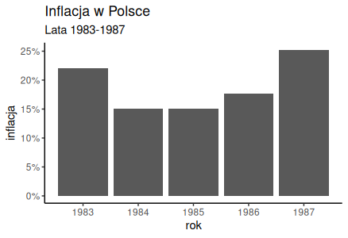

Wykres słupkowy z pełnym zasięgiem osi OY.

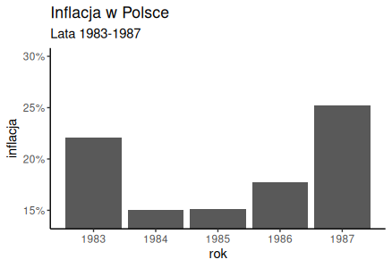

Wykres słupkowy z ograniczoną osią OY do przedziału na którym zachodzą zmiany.

## Otrzymane wyniki

[figure not shown]

## Opinie ankietowanych

Stosunek liczby ankietowanych, którzy określili wykres słupkowy z ograniczoną osią OY jako lepszy do tych, którzy stwierdzili przeciwnie, wynosi niemalże 1:1. Ten fakt może wskazywać na to, iż ludzie nie są w pełni świadomi ryzyka, które może powodować stosowanie w.w. ograniczeń na wykresach słupkowych.

## Wnioski

Zebrane wyniki potwierdzają spekulację, iż ludzie znacznie lepiej odczytują wysokości oraz ich proporcje z wykresów słupkowych, które nie mają ograniczonej osi OY. Ankietowani widocznie celniej radzili sobie z porównywaniem wartości zilustrowanych danych na wykresach bez ograniczonej osi OY. Prawdę mówiąc, w przeciwnym przypadku odchylenie od prawidłowego wyniku było znaczne - można to potraktować jako dowód na to, że lepiej nie “ucinać” wysokości słupkóW na wykresach, ponieważ zawarte w nich informacje mają tendencję do bycia interpretowanymi niedokładnie. Przypuszczamy, iż głównym powodem błędów oszacowań jest fakt, iż redukcja wysokości słupków wprowadza pewną nieintuicyjność u osób, które zamiast weryfikować wartości liczbowe słupków, zaledwie interpretują wizualnie ich rozmiar.